```r
library(ggplot2)
library(readr)
library(gridExtra)
library(dplyr)
library(GGally)
library(corrplot)
library(memisc)
df <- read.csv('wineQualityWhites.csv')
```

# Univariate Plots Section

```r
str(df)
```

```
## 'data.frame':    4898 obs. of  13 variables:
##  $ X                   : int  1 2 3 4 5 6 7 8 9 10 ...
##  $ fixed.acidity       : num  7 6.3 8.1 7.2 7.2 8.1 6.2 7 6.3 8.1 ...
##  $ volatile.acidity    : num  0.27 0.3 0.28 0.23 0.23 0.28 0.32 0.27 0.3 0.22 ...
##  $ citric.acid         : num  0.36 0.34 0.4 0.32 0.32 0.4 0.16 0.36 0.34 0.43 ...
##  $ residual.sugar      : num  20.7 1.6 6.9 8.5 8.5 6.9 7 20.7 1.6 1.5 ...
##  $ chlorides           : num  0.045 0.049 0.05 0.058 0.058 0.05 0.045 0.045 0.049 0.044 ...
##  $ free.sulfur.dioxide : num  45 14 30 47 47 30 30 45 14 28 ...
##  $ total.sulfur.dioxide: num  170 132 97 186 186 97 136 170 132 129 ...
##  $ density             : num  1.001 0.994 0.995 0.996 0.996 ...
##  $ pH                  : num  3 3.3 3.26 3.19 3.19 3.26 3.18 3 3.3 3.22 ...
##  $ sulphates           : num  0.45 0.49 0.44 0.4 0.4 0.44 0.47 0.45 0.49 0.45 ...
##  $ alcohol             : num  8.8 9.5 10.1 9.9 9.9 10.1 9.6 8.8 9.5 11 ...
##  $ quality             : int  6 6 6 6 6 6 6 6 6 6 ...
```

The white wine datasheet contains 4898 observations with 11 input variables on the chemical property and 1 input variable on the quality.

```r
summary(df)
```

```
##        X        fixed.acidity    volatile.acidity  citric.acid
##  Min.   :   1   Min.   : 3.800   Min.   :0.0800   Min.   :0.0000
##  1st Qu.:1225   1st Qu.: 6.300   1st Qu.:0.2100   1st Qu.:0.2700
##  Median :2450   Median : 6.800   Median :0.2600   Median :0.3200
##  Mean   :2450   Mean   : 6.855   Mean   :0.2782   Mean   :0.3342
##  3rd Qu.:3674   3rd Qu.: 7.300   3rd Qu.:0.3200   3rd Qu.:0.3900
##  Max.   :4898   Max.   :14.200   Max.   :1.1000   Max.   :1.6600
##  residual.sugar     chlorides       free.sulfur.dioxide
##  Min.   : 0.600   Min.   :0.00900   Min.   :  2.00
##  1st Qu.: 1.700   1st Qu.:0.03600   1st Qu.: 23.00
##  Median : 5.200   Median :0.04300   Median : 34.00
##  Mean   : 6.391   Mean   :0.04577   Mean   : 35.31
##  3rd Qu.: 9.900   3rd Qu.:0.05000   3rd Qu.: 46.00
##  Max.   :65.800   Max.   :0.34600   Max.   :289.00
##  total.sulfur.dioxide    density             pH          sulphates
##  Min.   :  9.0        Min.   :0.9871   Min.   :2.720   Min.   :0.2200
##  1st Qu.:108.0        1st Qu.:0.9917   1st Qu.:3.090   1st Qu.:0.4100
##  Median :134.0        Median :0.9937   Median :3.180   Median :0.4700
##  Mean   :138.4        Mean   :0.9940   Mean   :3.188   Mean   :0.4898
##  3rd Qu.:167.0        3rd Qu.:0.9961   3rd Qu.:3.280   3rd Qu.:0.5500
##  Max.   :440.0        Max.   :1.0390   Max.   :3.820   Max.   :1.0800
##     alcohol         quality
##  Min.   : 8.00   Min.   :3.000
##  1st Qu.: 9.50   1st Qu.:5.000
##  Median :10.40   Median :6.000
##  Mean   :10.51   Mean   :5.878
##  3rd Qu.:11.40   3rd Qu.:6.000
##  Max.   :14.20   Max.   :9.000
```

The quality is integer from 1(or 0?) to 10. The medan is 5.878 and the median is 6. However, the lowest score in the datasheet is 3 and the highest score is 9. Therefore, a categorical variable quality_factor coule be created.

The minimum values in all variables are larger than 0 except that in the citric. acid.

It’s rare to find wines with residual.sugar less than 1g/L or greater than 45g/L which is considered as sweet wines. A logical factor is_sweet is created to tell whether it’s sweet or not.

With free SO2 concentrations over 50 ppm, SO2 becomes evident in the nose and taste of wine. A categorical factor SO2_evident is created to tell whether it’s evident.

The total SO2 consists of free and bounded SiO2, whereas the latter could be derived. A numerical variable bound.sulfur.dioxide is created.

pH are mostly ranging from 3-4 (median:3.180,mean:3.188,max:3.820,min:2.720). pH below 3 is considered as acid. A categorical factor acid_factor is created to tell whether it’s evident.

```r
df$quality_factor <- factor (df$quality)
df$is_sweet<-ifelse(df$residual.sugar>45,TRUE,FALSE)
df$SO2_evident<-factor(ifelse(df$free.sulfur.dioxide>50,'Evident','Regular'))
df$bound.sulfur.dioxide<-df$total.sulfur.dioxide-df$free.sulfur.dioxide
df$acid_factor<-factor(ifelse(df$pH<3,'Acidic','Regular'))

summary(df)
```

```
##        X        fixed.acidity    volatile.acidity  citric.acid
##  Min.   :   1   Min.   : 3.800   Min.   :0.0800   Min.   :0.0000
##  1st Qu.:1225   1st Qu.: 6.300   1st Qu.:0.2100   1st Qu.:0.2700
##  Median :2450   Median : 6.800   Median :0.2600   Median :0.3200
##  Mean   :2450   Mean   : 6.855   Mean   :0.2782   Mean   :0.3342
##  3rd Qu.:3674   3rd Qu.: 7.300   3rd Qu.:0.3200   3rd Qu.:0.3900
##  Max.   :4898   Max.   :14.200   Max.   :1.1000   Max.   :1.6600
##
##  residual.sugar     chlorides       free.sulfur.dioxide
##  Min.   : 0.600   Min.   :0.00900   Min.   :  2.00
##  1st Qu.: 1.700   1st Qu.:0.03600   1st Qu.: 23.00
##  Median : 5.200   Median :0.04300   Median : 34.00
##  Mean   : 6.391   Mean   :0.04577   Mean   : 35.31
##  3rd Qu.: 9.900   3rd Qu.:0.05000   3rd Qu.: 46.00
##  Max.   :65.800   Max.   :0.34600   Max.   :289.00
##
##  total.sulfur.dioxide    density             pH          sulphates
##  Min.   :  9.0        Min.   :0.9871   Min.   :2.720   Min.   :0.2200
##  1st Qu.:108.0        1st Qu.:0.9917   1st Qu.:3.090   1st Qu.:0.4100
##  Median :134.0        Median :0.9937   Median :3.180   Median :0.4700
##  Mean   :138.4        Mean   :0.9940   Mean   :3.188   Mean   :0.4898
##  3rd Qu.:167.0        3rd Qu.:0.9961   3rd Qu.:3.280   3rd Qu.:0.5500
##  Max.   :440.0        Max.   :1.0390   Max.   :3.820   Max.   :1.0800
##
##     alcohol         quality      quality_factor  is_sweet
##  Min.   : 8.00   Min.   :3.000   3:  20         Mode :logical
##  1st Qu.: 9.50   1st Qu.:5.000   4: 163         FALSE:4897
##  Median :10.40   Median :6.000   5:1457         TRUE :1
##  Mean   :10.51   Mean   :5.878   6:2198
##  3rd Qu.:11.40   3rd Qu.:6.000   7: 880
##  Max.   :14.20   Max.   :9.000   8: 175
##                                  9:   5
##   SO2_evident   bound.sulfur.dioxide  acid_factor
##  Evident: 868   Min.   :  4.0        Acidic : 437
##  Regular:4030   1st Qu.: 78.0        Regular:4461
##                 Median :100.0
##                 Mean   :103.1
##                 3rd Qu.:125.0
##                 Max.   :331.0
##
```

Only 5 wines have a score of 9; Only 1 wine is sweet; 868 wines are SO2-evident; and 437 wines are acidic.

Now let’s look at the histogram of each variable.

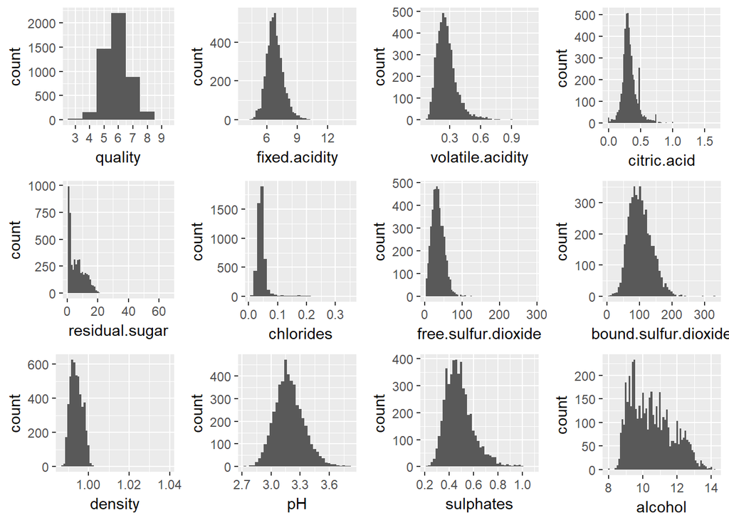

```r
p0 <-ggplot(aes(x=quality),data=df)+
  geom_histogram(binwidth=1)+
  scale_x_continuous(breaks=seq(0,10,1))

p1<-ggplot(aes(x=fixed.acidity),data=df)+
  geom_histogram(binwidth=0.2)+
  scale_x_continuous()

p2<-ggplot(aes(x=volatile.acidity),data=df)+
  geom_histogram(binwidth=0.02)+
  scale_x_continuous()

p3<-ggplot(aes(x=citric.acid),data=df)+
  geom_histogram(binwidth=0.02)+
  scale_x_continuous()

p4<-ggplot(aes(x=residual.sugar),data=df)+
  geom_histogram(binwidth=1)+
  scale_x_continuous()

p5<-ggplot(aes(x=chlorides),data=df)+
  geom_histogram()+
  scale_x_continuous()

p6<-ggplot(aes(x = free.sulfur.dioxide), data = df) +
  geom_histogram(binwidth = 4)

p7<-ggplot(aes(x = bound.sulfur.dioxide), data = df) +
  geom_histogram(binwidth = 6)

p8<-ggplot(aes(x = density), data = df) +
  geom_histogram(binwidth = 0.001)

p9<-ggplot(aes(x = pH), data = df) +
  geom_histogram(binwidth = 0.03)

p10<-ggplot(aes(x = sulphates), data = df) +
  geom_histogram(binwidth = 0.02)

p11<-ggplot(aes(x = alcohol), data = df) +
  geom_histogram(binwidth = 0.1)

grid.arrange(p0,p1,p2,
             p3,p4,p5,
             p6,p7,p8,
             p9,p10,p11,
             nrow=3,ncol=4)
```

most variables have bell-shape normal distribution,except the following: residual.sugar: long tail citric.acid: some spikes on the right side alcohol: dont’t know..

Hence for residual.sugar, the x-scale should be transformed with log10 function:

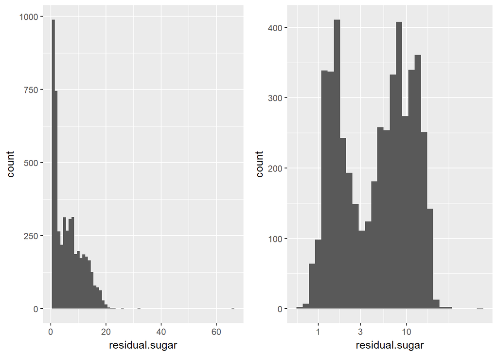

```r
#log scale
p4_log<-ggplot(aes(x=residual.sugar),data=df)+
  geom_histogram()+
  scale_x_log10(breaks=c(1,3,10))

grid.arrange(p4,p4_log,nrow = 1)
```

Using smaller bin and freqpoly, it becomes more clear

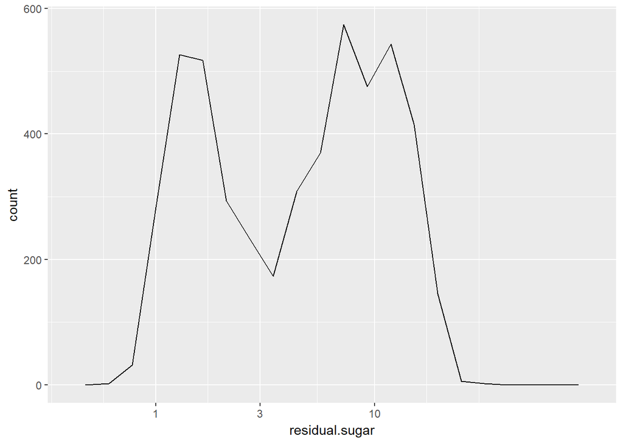

```r
ggplot(aes(x = residual.sugar), data = df) +
  geom_freqpoly(bins = 20) +
  scale_x_log10(breaks = c(1,3,10))
```

Using different bins to investigate citric.acid, more spikes (x=0.5 andx=0.72) appear besides the main one at x=0.3

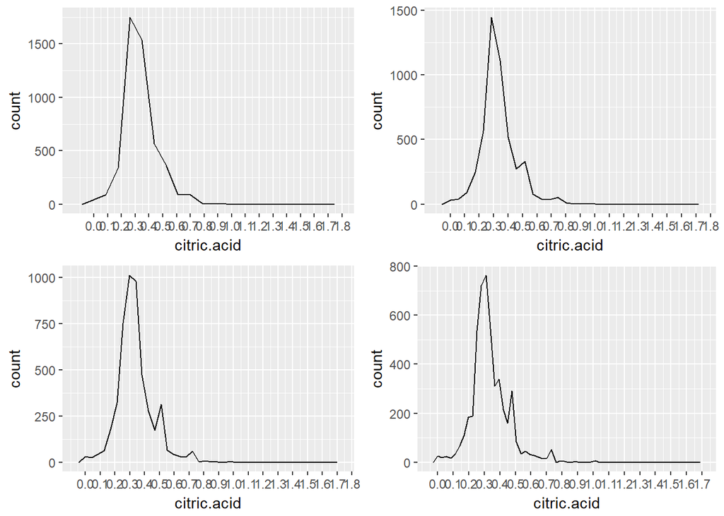

```r
p3a<-
  ggplot(aes(x = citric.acid), data = df) +
  geom_freqpoly(bins = 20) +
  scale_x_continuous(breaks = seq(0,2,0.1))
p3b<-
  ggplot(aes(x = citric.acid), data = df) +
  geom_freqpoly(bins = 30) +
  scale_x_continuous(breaks = seq(0,2,0.1))
p3c<-
  ggplot(aes(x = citric.acid), data = df) +
  geom_freqpoly(bins = 40) +
  scale_x_continuous(breaks = seq(0,2,0.1))

p3d<-
  ggplot(aes(x = citric.acid), data = df) +
  geom_freqpoly(bins = 60) +
  scale_x_continuous(breaks = seq(0,2,0.1))

grid.arrange(p3a,p3b,p3c, p3d,nrow = 2, ncol = 2)
```

The distribution of alcohol in the dataset follows a bell shape with smaller bins, and becomes noisy with more bins. This suggests a wide variance of alcohol.

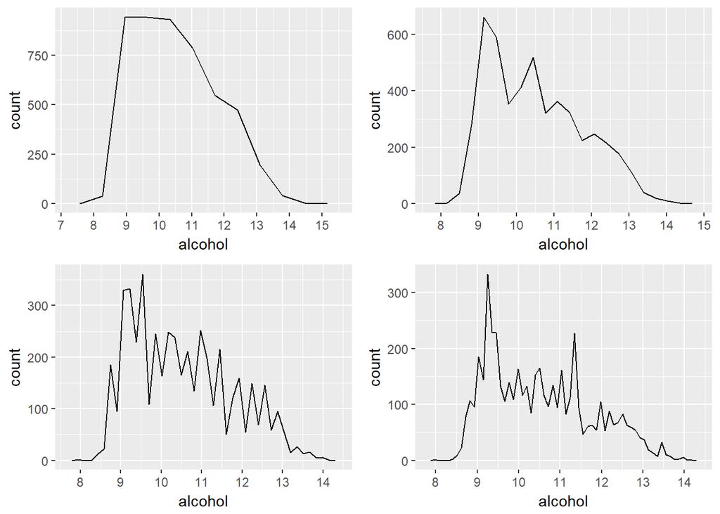

```r
p11a<-
  ggplot(aes(x = alcohol), data = df) +
  geom_freqpoly(bins = 10)  +
  scale_x_continuous(breaks = seq(0,15,1))

p11b<-
  ggplot(aes(x = alcohol), data = df) +
  geom_freqpoly(bins = 20)  +
  scale_x_continuous(breaks = seq(0,15,1))

p11c<-
  ggplot(aes(x = alcohol), data = df) +
  geom_freqpoly(bins = 40)  +
  scale_x_continuous(breaks = seq(0,15,1))

p11d<-
  ggplot(aes(x = alcohol), data = df) +
  geom_freqpoly(bins = 60) +
  scale_x_continuous(breaks = seq(0,15,1))

grid.arrange(p11a,p11b,p11c, p11d,nrow = 2, ncol = 2)
```

In addition, there are outliers in certain vailables; they will be removed in the analysis later.

# Univariate Analysis

### What is the structure of the dataset?

The white wine datasheet contains 4898 observations with 11 input variables on the chemical property and 1 input variable on the quality.

### What is the main interest?

The correlation between variables and the quality are the main interest.

### What are the features in the dataset?

All variables could influence the quality; however, residual.sugar has a different distribution compared with other variables and alcohol does not have a clear distribution shape. These are the 2 variables that draw the most attention. Of course, no conclusion could be drawn at this point.

### Are there any created variables?

Yes. 5 variables are created: 1 numerical variable bound.sulfur.dioxide, 1 logical variable is_sweet, 3 catagorical variables quality_factor, SO2_evident, acid_factor. Bucket may also be necessary in the analysis later.

### Are there any unusual distributions? Any transform/operations with them?

Yes, residual.sugar has a different distributions and a log_10 scale has been applied.

In addition, different bins are tested to capture the feature of the data, some spikes appear with smaller binwidth.

Last but not least, there are some outliers in the data. They are not removed yet, because the underlying correlation is not clear at this point.

# Bivariate Plots Section

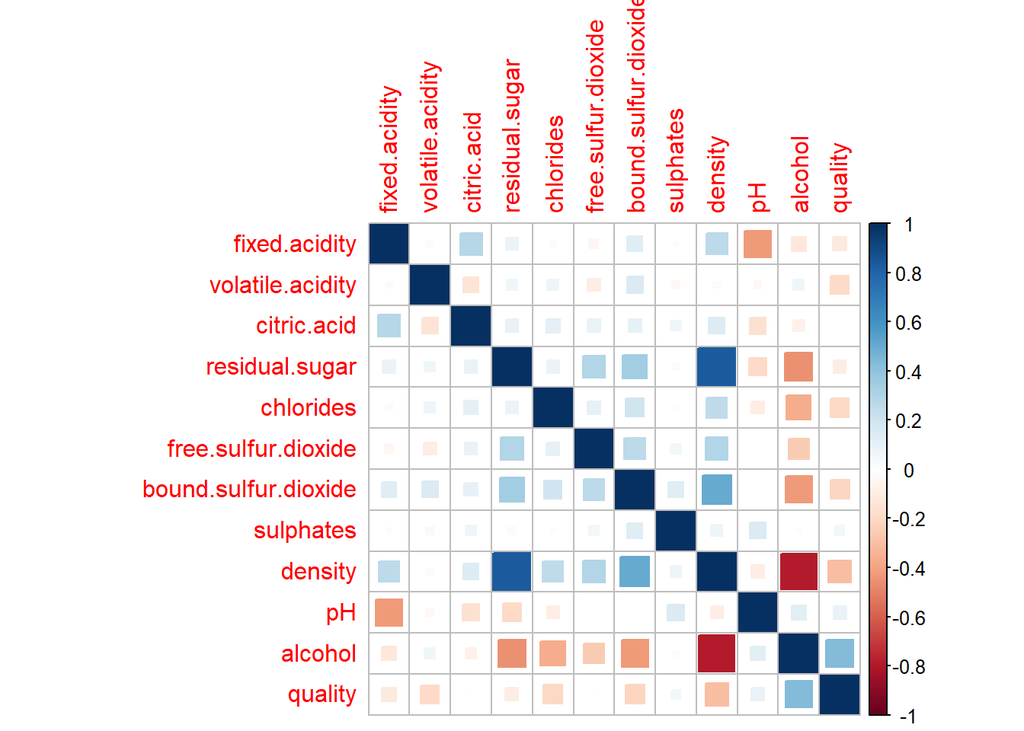

```r
df_subset <- subset(df,select = c("fixed.acidity","volatile.acidity","citric.acid","residual.sugar","chlorides" ,
                                  "free.sulfur.dioxide","bound.sulfur.dioxide","sulphates",
                                  "density", "pH","alcohol","quality"))
M<-cor(df_subset)
corrplot(M,method = 'square')
```

Using corrplot, the correlations among pairs of the variables are clear and we are interested between each variable and the quality.

All correlation ranking from the highest to the lowest: 1-alcohol 0.431 2-density -0.298 3-chlorides -0.224 4-bound.sulfur.dioxide -0.221 5-volatile.acidity -0.181 6-pH 0.128 7-residual.sugar -0.103 8-fixed.acidity -0.0789 9-sulphates 0.0548 10-free.sulfur.dioxide 0.0387 11-citric.acid -0.0366.

All correlations are not strong. The highest 4 correlations are alcohol, density, chlorides and bound.sulfur.dioxide.The scatterplot are created, with top 0.1% of the data is removed.

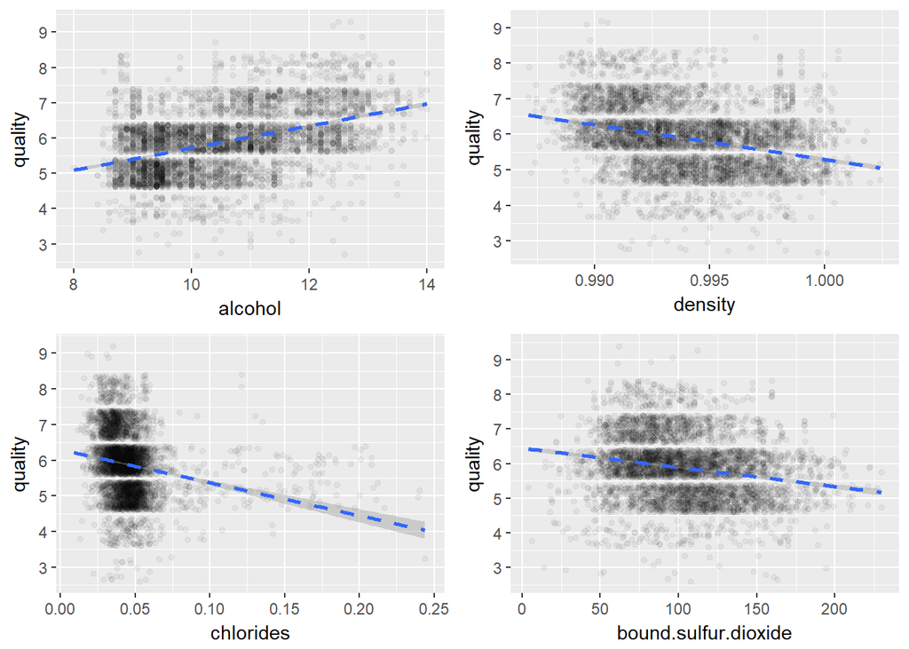

```r
pc1<- ggplot(aes(x=alcohol,y=quality),data=df)+
  geom_jitter(alpha=0.05,size=1.2)+
  scale_y_continuous(breaks=seq(3,9,1))+
  geom_smooth(method='lm',linetype=2)+
  xlim(min(df$alcohol),quantile(df$alcohol,0.999))

pc2<- ggplot(aes(x=density,y=quality),data=df)+
  geom_jitter(alpha=0.05,size=1.2)+
  scale_y_continuous(breaks=seq(3,9,1))+
  geom_smooth(method='lm',linetype=2)+
  xlim(min(df$density),quantile(df$density,0.999))

pc3<-ggplot(aes(x=chlorides,y=quality),data=df)+
  geom_jitter(alpha=0.05,size=1.2)+
  scale_y_continuous(breaks=seq(3,9,1))+
  geom_smooth(method='lm',linetype=2)+
  xlim(min(df$chlorides),quantile(df$chlorides,0.999))

pc4<-ggplot(aes(x=bound.sulfur.dioxide,y=quality),data=df)+
  geom_jitter(alpha=0.05,size=1.2)+
  scale_y_continuous(breaks=seq(3,9,1))+
  geom_smooth(method='lm',linetype=2)+
  xlim(min(df$bound.sulfur.dioxide),quantile(df$bound.sulfur.dioxide,0.999))

grid.arrange(pc1,pc2,pc3,pc4,nrow=2,ncol=2)
```

It seems that wines with higher quality tend to have higher alcohol, lower density, lower chlorides and lower bound.sulfur.dioxide. However for chlorides, it seems that the negative correlation may be driven by the outliers. Hence for this particular pair, the quantile is reduced to 0.95.

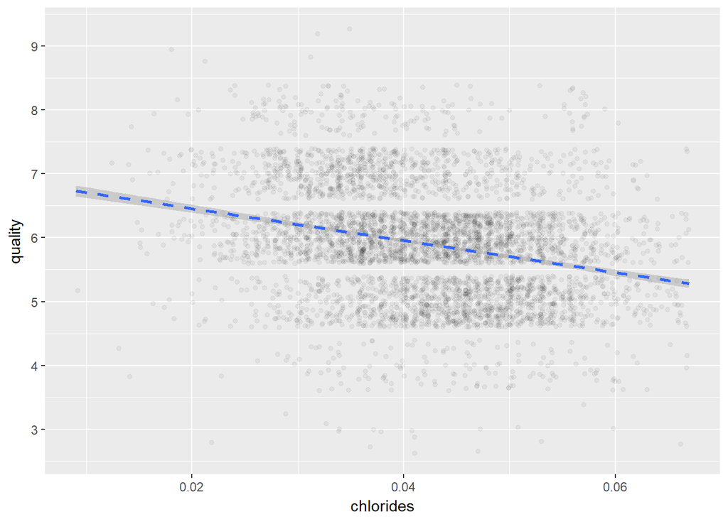

```r
ggplot(aes(x=chlorides,y=quality),data=df)+
  geom_jitter(alpha=0.05,size=1.2)+
  scale_y_continuous(breaks=seq(3,9,1))+
  geom_smooth(method='lm',linetype=2)+
  xlim(min(df$chlorides),quantile(df$chlorides,0.95))
```

1. alcohol

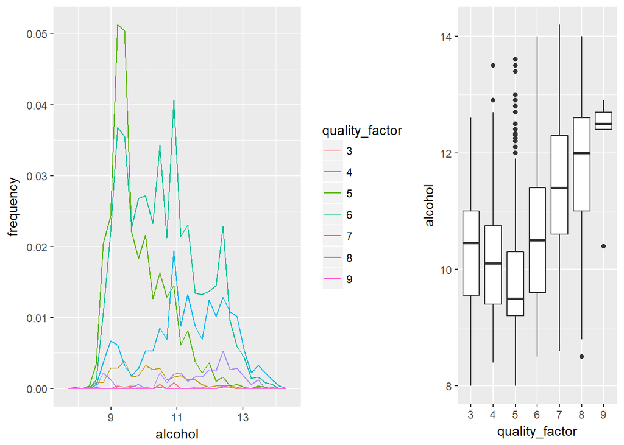

```r
pr11<-ggplot(aes(x = alcohol, y = ..count../sum(..count..)), data = df) +
  geom_freqpoly(aes(color = quality_factor)) +
  ylab('frequency')

pb11<-ggplot(aes(x = quality_factor,y = alcohol), data = df) +
  geom_boxplot()

grid.arrange(pr11,pb11,nrow=1,widths=2:1)
```

Alcohol does not always show clear peaks but in general, the plot shifts to the right side with increasing quality.

In the box plot, it shows a U trend with lowest median occuring in the wines of quality of 5. Higher quality wines tend to have higher alcohol.

2. density

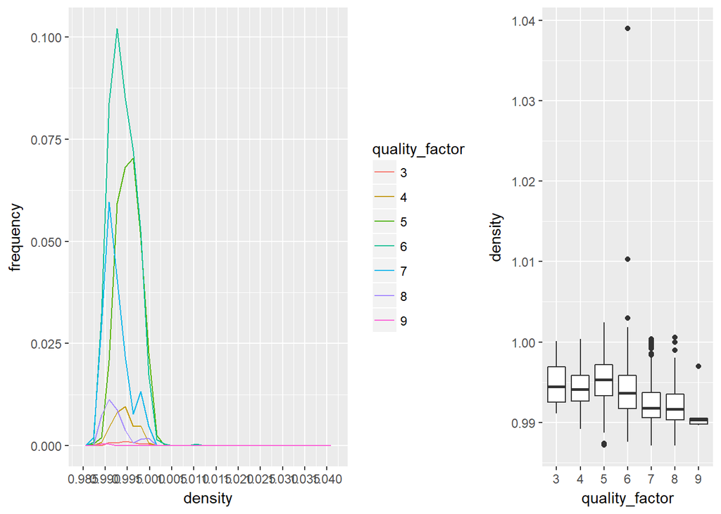

```r
pr8<-ggplot(aes(x = density, y = ..count../sum(..count..)), data = df) +
  geom_freqpoly(aes(color = quality_factor)) +
  ylab('frequency')+
  scale_x_continuous(breaks = seq(0.9,1.04,0.005))

pb8<-ggplot(aes(x = quality_factor,y = density), data = df) +
  geom_boxplot()

grid.arrange(pr8,pb8,nrow=1,widths=2:1)
```

In freqpoly, density is shifting to the left as quality goes higher, and in boxplot, density goes down as quality goes up. Such negative trend is consistent with the calculated correlation coefficient.

3. chlorides

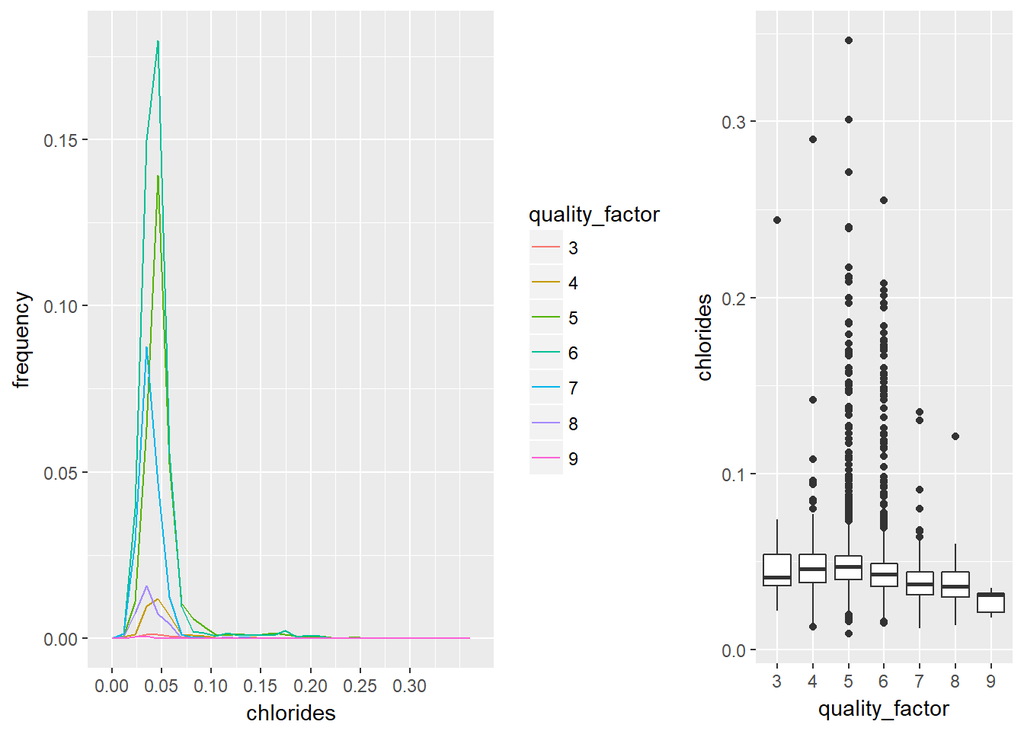

```r
pr5<-ggplot(aes(x = chlorides, y = ..count../sum(..count..)), data = df) +
  geom_freqpoly(aes(color = quality_factor)) +
  ylab('frequency')+
  scale_x_continuous(breaks=seq(0,0.3,0.05))

pb5<-ggplot(aes(x = quality_factor,y = chlorides), data = df) +
  geom_boxplot()

grid.arrange(pr5,pb5,nrow=1,widths = 2:1)
```

Chlorides is similar to density, which also shows a left shift of the peak in freqpoly, and downward trend in boxplot. Notice there are a lot of outliers shown in the boxplot, which can also be seen in freqpoly. The outliers could be removed for better visuallization.

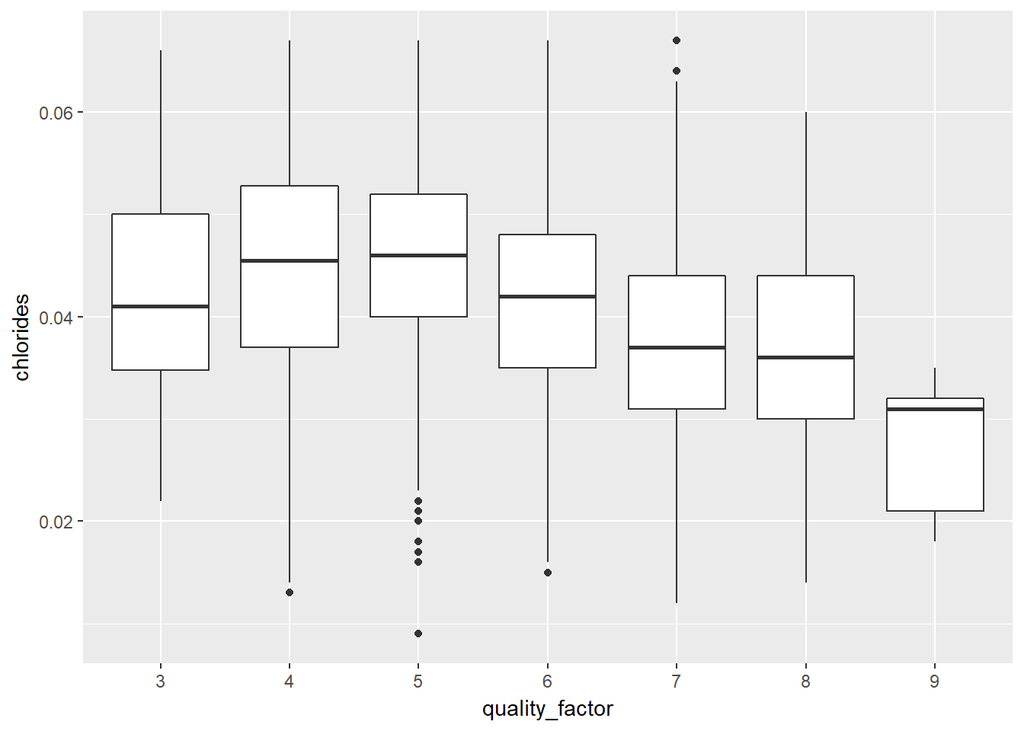

```r
ggplot(aes(x = quality_factor,y = chlorides), data = df) +
  geom_boxplot() +
  ylim(min(df$chlorides),quantile(df$chlorides,0.95))
```

After removing the outliers, a clear down trend could be seen.

4.bound.sulfur.dioxide

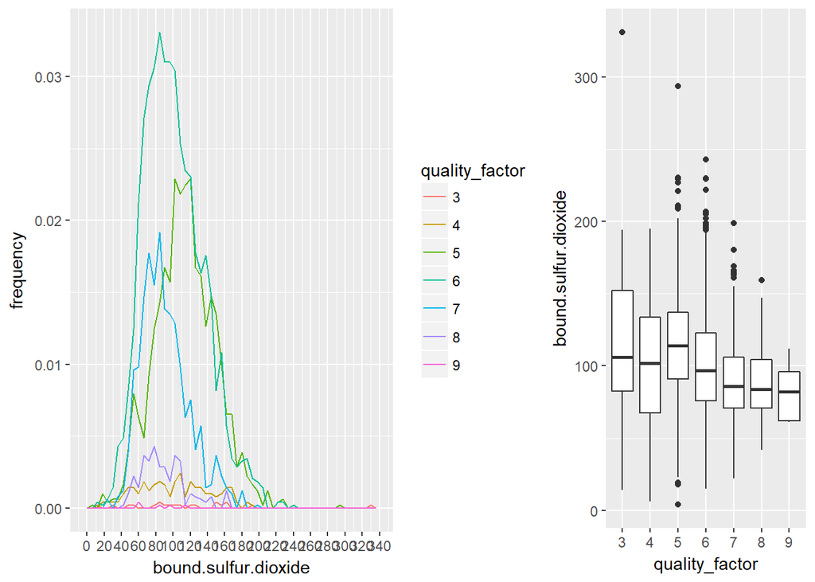

```r
pr7<-
  ggplot(aes(x = bound.sulfur.dioxide, y = ..count../sum(..count..)), data = df) +
  geom_freqpoly(aes(color = quality_factor),binwidth = 6) +
  ylab('frequency')+
  scale_x_continuous(breaks = seq(0,340,20))
pb7<-ggplot(aes(x = quality_factor,y = bound.sulfur.dioxide), data = df) +
  geom_boxplot()

grid.arrange(pr7,pb7,nrow=1,widths = 2:1)
```

It is also suggested by this figure that with increasing quality_factor, the bound SO2 decreases.

5. volatile.acidity

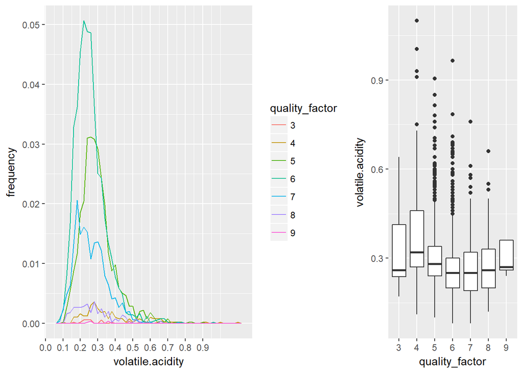

```r
pr2<-
  ggplot(aes(x = volatile.acidity, y = ..count../sum(..count..)), data = df) +
  geom_freqpoly(aes(color = quality_factor),binwidth = 0.02) +
  ylab('frequency') +
  scale_x_continuous(breaks = seq(0,0.9,0.1))
pb2<-ggplot(aes(x = quality_factor,y = volatile.acidity), data = df) +
  geom_boxplot()

grid.arrange(pr2,pb2,nrow=1,widths = 2:1)
```

There is a left-shift of the peak in freqpoly with quality of 5 and 6. In addition, the trend is less obvious.

6. pH

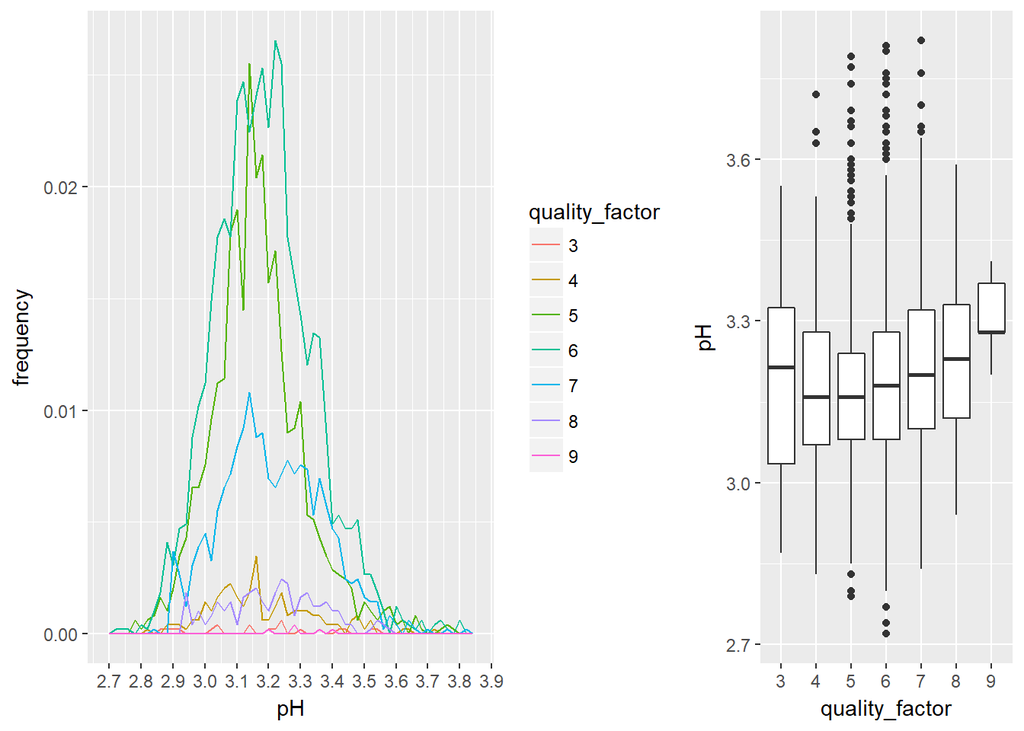

```r
pr9<-
  ggplot(aes(x = pH, y = ..count../sum(..count..)), data = df) +
  geom_freqpoly(aes(color = quality_factor),binwidth = 0.02) +
  ylab('frequency')+
  scale_x_continuous(breaks = seq(2.7,3.9,0.1))
pb9<-ggplot(aes(x = quality_factor,y = pH), data = df) +
  geom_boxplot()

grid.arrange(pr9,pb9,nrow=1,widths = 2:1)
```

For PH, the freqpoly shows similar distritbuion for different quality, and there seems to be an uptrend for the quality_factor.

7.residual.sugar

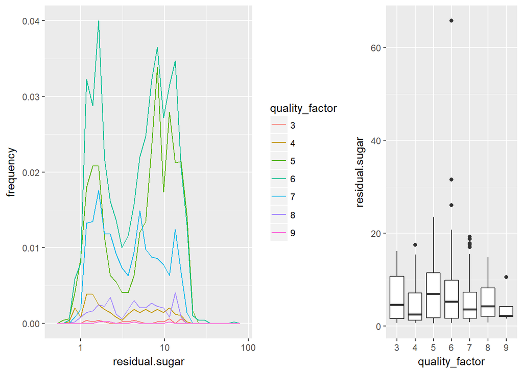

```r
pr4<-
  ggplot(aes(x = residual.sugar, y = ..count../sum(..count..)), data = df) +
  geom_freqpoly(aes(color = quality_factor)) +
  ylab('frequency') +
  scale_x_log10()
pb4<-ggplot(aes(x = quality_factor,y = residual.sugar), data = df) +
  geom_boxplot()

grid.arrange(pr4,pb4,nrow=1,widths = 2:1)
```

Residual sugar shows bimodal distribution in freqploy but seems no difference in the boxplot. Any there is one sweet wine as discussed in part1, which is clearly seen as an outlier at quality factor of 6.

8. fixed.acidity

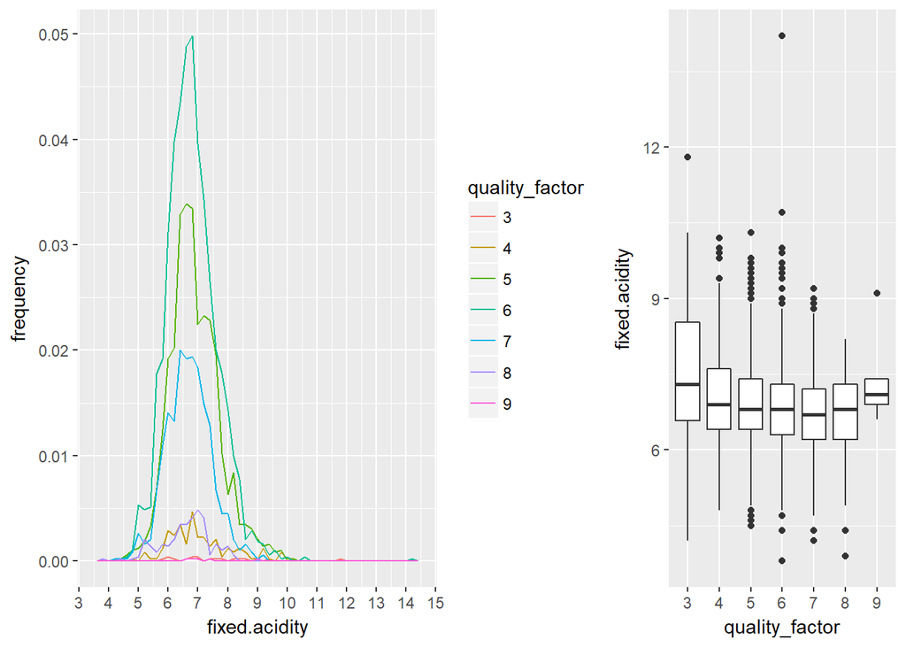

```r
pr1<-
  ggplot(aes(x = fixed.acidity, y = ..count../sum(..count..)), data = df) +
  geom_freqpoly(aes(color = quality_factor),binwidth = 0.2) +
  ylab('frequency') +
  scale_x_continuous(breaks = seq(3,15,1))
pb1<-
  ggplot(aes(x = quality_factor,y = fixed.acidity), data = df) +
  geom_boxplot()

grid.arrange(pr1,pb1,nrow=1,widths = 2:1)
```

Fixed acidity shows similar distribution across different quality. There is no clear trend in the boxplot.

9. sulphates

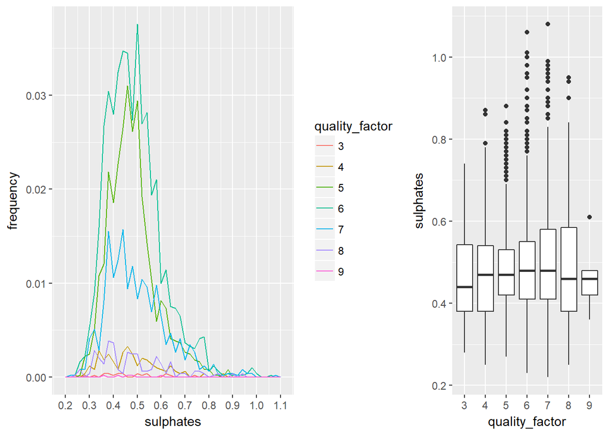

```r
pr10<-
  ggplot(aes(x = sulphates, y = ..count../sum(..count..)), data = df) +
  geom_freqpoly(aes(color = quality_factor),binwidth = 0.02) +
  ylab('frequency')+
  scale_x_continuous(breaks = seq(0.2,1.2,0.1))
pb10<-ggplot(aes(x = quality_factor,y = sulphates), data = df) +
  geom_boxplot()

grid.arrange(pr10,pb10,nrow=1,widths = 2:1)
```

It’s same that sulphates shows similar distribution across different quality. There is no clear trend in the boxplot.

11. citric.acid

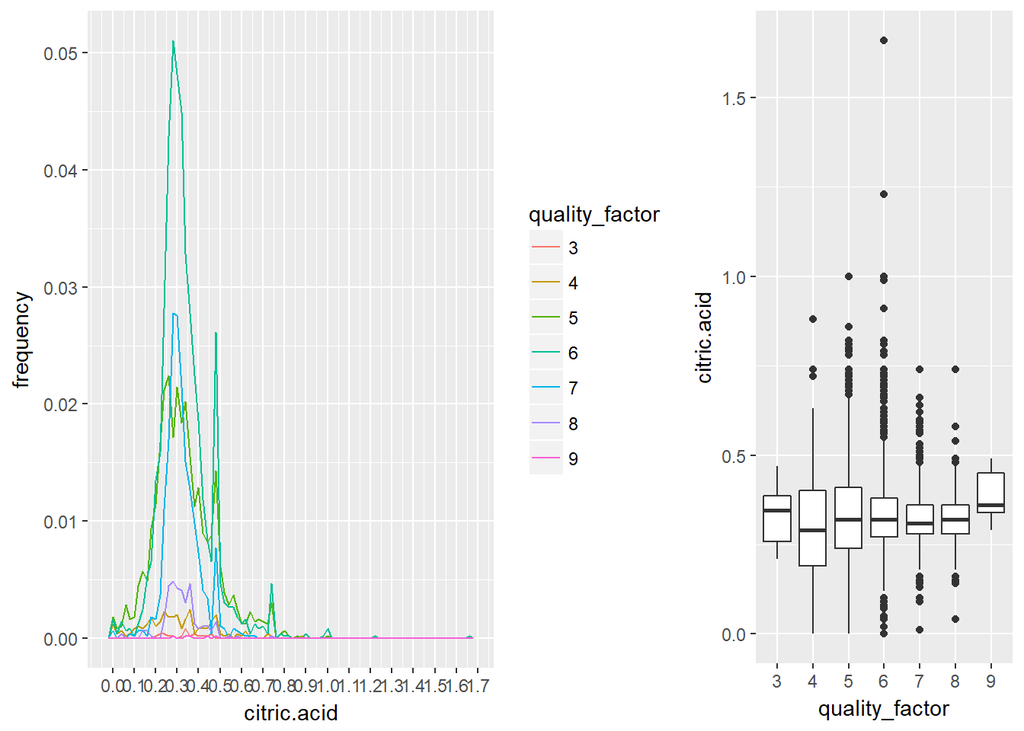

```r
pr3<-
  ggplot(aes(x = citric.acid, y = ..count../sum(..count..)), data = df) +
  geom_freqpoly(aes(color = quality_factor),binwidth = 0.02) +
  ylab('frequency') +
  scale_x_continuous(breaks = seq(0,2,0.1))
pb3<-ggplot(aes(x = quality_factor,y = citric.acid), data = df) +
  geom_boxplot()

grid.arrange(pr3,pb3,nrow=1,widths = 2:1)
```

It’s same that citric acid shows similar distribution across different quality. There is no clear trend in the boxplot and a large number of outliers could be seen.

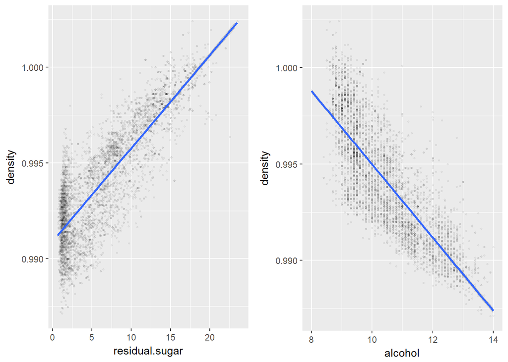

```r
pd1<-
  ggplot(aes(x = residual.sugar, y = density),data = df)+
  geom_jitter(alpha = 1/20, size = 0.5)+
  xlim(min(df$residual.sugar),quantile(df$residual.sugar,0.999)) +
  ylim(min(df$density),quantile(df$density,0.999)) +
  geom_smooth(method = 'lm')

pd2<-
  ggplot(aes(x = alcohol, y = density),data = df)+
  geom_jitter(alpha = 1/20, size = 0.5)+
  xlim(min(df$alcohol),quantile(df$alcohol,0.999)) +
  ylim(min(df$density),quantile(df$density,0.999)) +
  geom_smooth(method = 'lm')

grid.arrange(pd1,pd2,nrow = 1)
```

Higher residal sugar and lower alcohol tend to correlate with higher density of the wine. And wine with higher quality tend to have lower density. Although the correlation is weak, we could see the trend at population level.

# Bivariate Analysis

## Could you find some relationships in this part? How does this feature vary with other features in the dataset?

Actually, non of the variable is strongly correlated with the quality. Most variables even have similar distribution with different quality factors.

Quality shows a downward trend against density, chlorides, bound SO2. Quality shows a U shape trend against alcohol with the lowest median at 5, and higher quality wines tend to have higher alcohol at range 5-9.

From part1, we learned that the median of quality is 6, therefore, for wines above median, better wines tend to have more alohol, higher pH, lower residual sugar,lower density and lower bound SO2.

## Any observation which is not the main features?

Yes, it is found that density is strongly correlated with residual sugar and alcohol. It could be explained that because the density of alcohol is less than that of water, the more the alcohol is, the lower the density is.

## What is the strongest correlation between any two vatiables?

Between density and alcohol/residual sugar.

# Multivariate Plots Section

Residual sugar is bimodal distributed, two buckets could be created to separate the two modes.

```r
residual.sugar_bucket = c(0,4,max(df$residual.sugar))
df$residual.sugar_bucket <- cut(df$residual.sugar,breaks =
                                residual.sugar_bucket,
                                include.lowest = FALSE,right = TRUE)
```

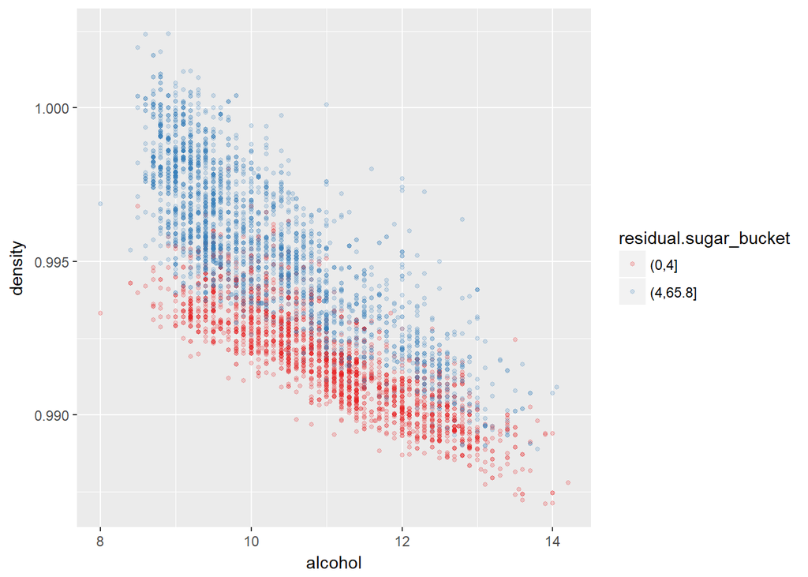

```r
ggplot(aes(x = alcohol, y = density,color = residual.sugar_bucket),data = df)+
  geom_point(alpha = 1/5,size = 1)+
  ylim(min(df$density),quantile(df$density,0.999))  +
  scale_color_brewer(type = 'qual', palette = 6)
```

It is clear that higher sugar tends to have a higher density.

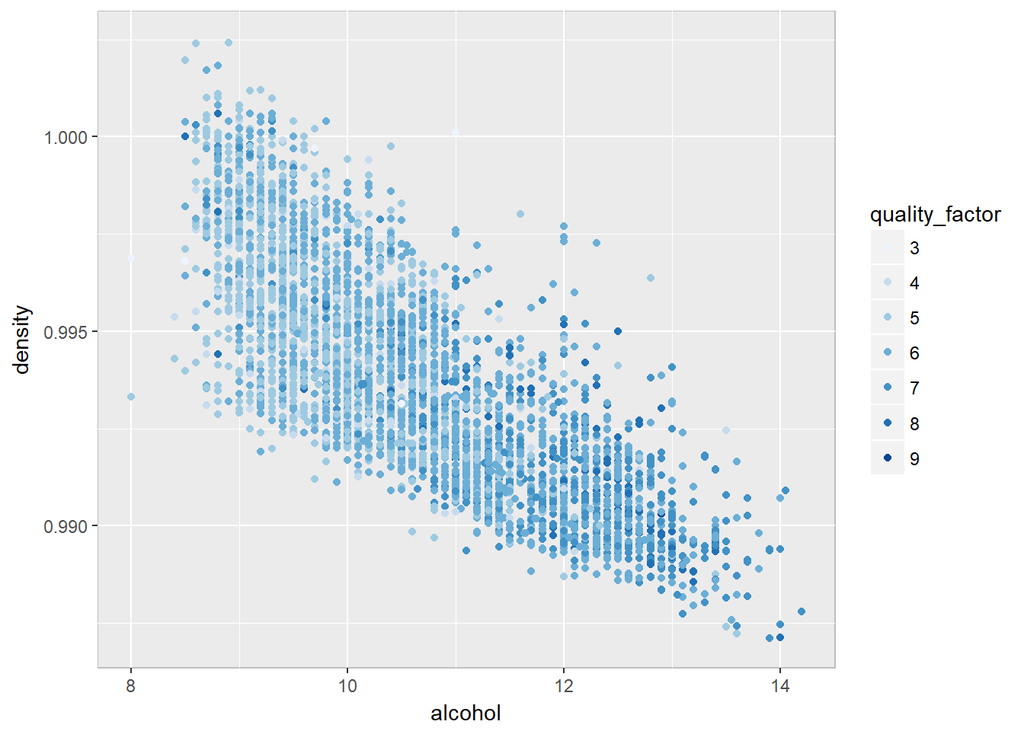

```r
ggplot(aes(x = alcohol, y = density,color = quality_factor),data = df)+
  geom_point()+
  ylim(min(df$density),quantile(df$density,0.999)) +
  scale_color_brewer(type = 'seq') +
  theme(panel.background = element_rect(color = 'grey'))
```

If we plot the alcohol and density with different quality, it could be seen that higher quality tends to have higher alcohol and lower density.

Although the correlation is not strong for any variable, it could be tried to do build a linear regression model.

```r
m1 <- lm(I(quality) ~ I(alcohol), data = df)
m2 <- update(m1, ~ . + density)
m3 <- update(m2, ~ . + chlorides)
m4 <- update(m3, ~ . + bound.sulfur.dioxide)
m5 <- update(m4, ~ . + volatile.acidity)
m6 <- update(m5, ~ . + pH)
m7 <- update(m6, ~ . + log(residual.sugar))
m8 <- update(m7, ~ . + fixed.acidity)
m9 <- update(m8, ~ . + sulphates)
m10 <- update(m9, ~ . + free.sulfur.dioxide)
m11 <- update(m10, ~ . + citric.acid)

mtable(m1,m2,m3,m4,m5,m6,m7,m8,m9,m10,m11,sdigits = 3)
```

```
##
## Calls:
## m1: lm(formula = I(quality) ~ I(alcohol), data = df)
## m2: lm(formula = I(quality) ~ I(alcohol) + density, data = df)
## m3: lm(formula = I(quality) ~ I(alcohol) + density + chlorides, data = df)
## m4: lm(formula = I(quality) ~ I(alcohol) + density + chlorides +
##     bound.sulfur.dioxide, data = df)
## m5: lm(formula = I(quality) ~ I(alcohol) + density + chlorides +
##     bound.sulfur.dioxide + volatile.acidity, data = df)
## m6: lm(formula = I(quality) ~ I(alcohol) + density + chlorides +
##     bound.sulfur.dioxide + volatile.acidity + pH, data = df)
## m7: lm(formula = I(quality) ~ I(alcohol) + density + chlorides +
##     bound.sulfur.dioxide + volatile.acidity + pH + log(residual.sugar),
##     data = df)
## m8: lm(formula = I(quality) ~ I(alcohol) + density + chlorides +
##     bound.sulfur.dioxide + volatile.acidity + pH + log(residual.sugar) +
##     fixed.acidity, data = df)
## m9: lm(formula = I(quality) ~ I(alcohol) + density + chlorides +
##     bound.sulfur.dioxide + volatile.acidity + pH + log(residual.sugar) +
##     fixed.acidity + sulphates, data = df)
## m10: lm(formula = I(quality) ~ I(alcohol) + density + chlorides +
##     bound.sulfur.dioxide + volatile.acidity + pH + log(residual.sugar) +
##     fixed.acidity + sulphates + free.sulfur.dioxide, data = df)
## m11: lm(formula = I(quality) ~ I(alcohol) + density + chlorides +
##     bound.sulfur.dioxide + volatile.acidity + pH + log(residual.sugar) +
##     fixed.acidity + sulphates + free.sulfur.dioxide + citric.acid,
##     data = df)
##
## ==================================================================================================================================================================================
##                              m1            m2            m3            m4            m5            m6            m7            m8            m9           m10           m11
## ----------------------------------------------------------------------------------------------------------------------------------------------------------------------------------
##   (Intercept)               2.582***    -22.492***    -21.150***    -28.574***    -37.140***    -38.114***     47.415***     39.008***     49.709***     47.336***     47.757***
##                            (0.098)       (6.165)       (6.162)       (6.437)       (6.252)       (6.255)       (9.611)      (11.254)      (11.401)      (11.382)      (11.437)
##   I(alcohol)                0.313***      0.360***      0.343***      0.341***      0.388***      0.385***      0.295***      0.306***      0.290***      0.297***      0.296***
##                            (0.009)       (0.015)       (0.015)       (0.015)       (0.015)       (0.015)       (0.017)       (0.018)       (0.019)       (0.019)       (0.019)
##   density                                24.728***     23.671***     31.315***     39.834***     40.147***    -45.961***    -37.190**     -48.030***    -45.796***    -46.226***
##                                          (6.079)       (6.074)       (6.369)       (6.187)       (6.182)       (9.603)      (11.382)      (11.531)      (11.510)      (11.567)
##   chlorides                                            -2.382***     -2.245***     -1.278*       -1.198*       -0.616        -0.683        -0.688        -0.796        -0.818
##                                                        (0.558)       (0.558)       (0.543)       (0.543)       (0.538)       (0.540)       (0.539)       (0.538)       (0.541)
##   bound.sulfur.dioxide                                               -0.001***     -0.000        -0.000        -0.000        -0.000        -0.001        -0.001*       -0.001*
```

[output cut: 12 more lines]

```
##                                                                                                                                                          (0.001)       (0.001)
##   citric.acid                                                                                                                                                           0.037
##                                                                                                                                                                        (0.096)
## ----------------------------------------------------------------------------------------------------------------------------------------------------------------------------------
##   R-squared                 0.190         0.192         0.195         0.198         0.248         0.249         0.269         0.270         0.274         0.278         0.278
##   adj. R-squared            0.190         0.192         0.195         0.197         0.247         0.248         0.268         0.269         0.273         0.276         0.276
##   sigma                     0.797         0.796         0.795         0.793         0.768         0.768         0.758         0.757         0.755         0.753         0.754
##   F                      1146.395       583.290       396.315       301.971       322.520       270.670       257.601       225.707       204.909       187.895       170.797
##   p                         0.000         0.000         0.000         0.000         0.000         0.000         0.000         0.000         0.000         0.000         0.000
##   Log-likelihood        -5839.391     -5831.127     -5822.011     -5814.298     -5656.877     -5652.456     -5585.874     -5584.843     -5570.653     -5557.897     -5557.825
##   Deviance               3112.257      3101.773      3090.247      3080.530      2888.745      2883.534      2806.195      2805.014      2788.808      2774.320      2774.238
##   AIC                   11684.782     11670.255     11654.021     11640.596     11327.754     11320.911     11189.749     11189.686     11163.306     11139.794     11141.649
##   BIC                   11704.272     11696.241     11686.504     11679.576     11373.230     11372.884     11248.218     11254.651     11234.769     11217.753     11226.105
##   N                      4898          4898          4898          4898          4898          4898          4898          4898          4898          4898          4898
## ==================================================================================================================================================================================
```